# Lab1

Andreas C Charitos-andch552

21 Nov 2018

## Assignment 1

### 1

### 2

```
## [1] "The confusion matrix for train data is :"
```

```
##            True train values
## Predictions   0   1
##           0 803  81
##           1 142 344
```

```
## =====================================
## Accuracy on train data is:  0.8372263
## Precision on train data is: 0.908371
```

```
## [1] "The confusion matrix for test data is :"
```

```
##           True test values
## Prediction   0   1
##          0 791  97
##          1 146 336
```

```
## =====================================
## Accuracy on test data is:  0.8226277
## Precision on test data is: 0.8907658
```

```
## =====================================
## Missclasification error in train:  0.1627737
## Missclasification error in test: 0.1773723
```

### 3

```
## [1] "The confusion matrix for the train data is :"
```

```
##            True train values
## Predictions   0   1
##           0 944 419
##           1   1   6
```

```
## =====================================
## Accuracy on train data is:  0.6934307
```

```
## [1] "The confusion matrix for test data is :"
```

```
##            True train values
## Predictions   0   1
##           0 936 427
##           1   1   6
```

```
## =====================================
## Accuracy on test data is:  0.6875912
```

```
## =====================================
## Missclasification error in train:  0.3065693
## Missclasification error in test: 0.3124088
```

Comparing the results with question 2 we can see that when using a higher threshold more data clasiffied as not spam when they where spam actually resulting higher misclasification rate and lower accuracy than using a lower therhold.That is because the higher threshold is more likely to predict and obs as not spam.

### 4

```
##
## Call:
## kknn(formula = Spam ~ ., train = strain, test = strain, k = 30)
##
## Response: "nominal"
```

```
##                Real class
## Predicted class   0   1
##               0 807  98
##               1 138 327
```

```
##
## Call:
## kknn(formula = Spam ~ ., train = strain, test = stest, k = 30)
##
## Response: "nominal"
```

```
##                Real class
## Predicted class   0   1
##               0 672 187
##               1 265 246
```

```
## =====================================
## Missclasification error in train:  0.1722628
## Missclasification error in test: 0.329927
```

```
##
## =====================================
## Accuracy in train:  0.8277372
## Accuracy in test: 0.670073
```

Using KNN with 30 neightbours we can see that misclassification and test data is 0.1722 and 0.3299 repsectfully,Regarding the results for step 2 we have roughly the same accuracy and misclassification error in train data but we have higher misclasification error and lower accuracy on the test data.

### 5

```
##
## Call:
## kknn(formula = Spam ~ ., train = strain, test = strain, k = 1)
##
## Response: "nominal"
```

```
##                Real class
## Predicted class   0   1
##               0 945   0
##               1   0 425
```

```
##
## Call:
## kknn(formula = Spam ~ ., train = strain, test = stest, k = 1)
##
## Response: "nominal"
```

```
##                Real class
## Predicted class   0   1
##               0 640 177
##               1 297 256
```

```
## =====================================
## Missclasification error in train:  0
## Missclasification error in test: 0.3459854
```

When decreasing K we can see that the misclassification error for the test data remains roughly the same but when comparing the misclasification errors for the train data the error is 0 for the K=1.This is beacause model is looking for only one closest neightbour and that tend to make model ovarfiting.We can also support this claim comparing the confusion matrices.Again for test data confusion matrices they are roughly the same but regarding train data the model with k=1 does a very high accurate predictions finding the true class for every observation in train data as we can see from confusion matrix there is 0 (TypeI) and (Type II) error.

## Assignment 3

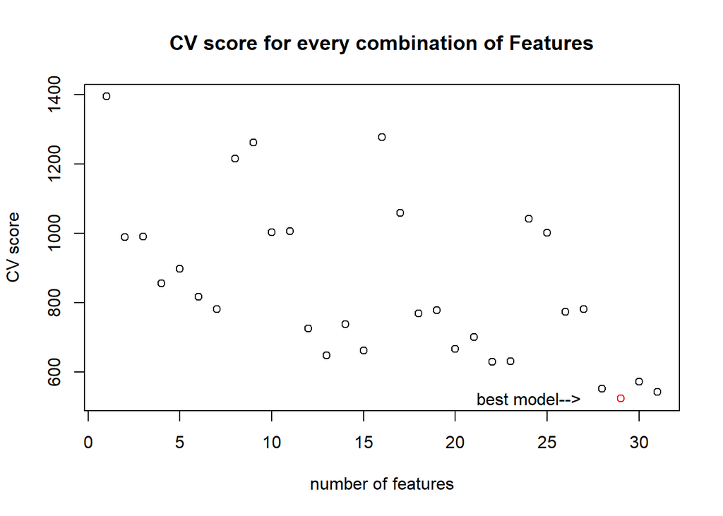

```
## $`best combination`
## [1] "Agriculture"      "Education"        "Catholic"
## [4] "Infant.Mortality"
##
## $`best cv score`
## [1] 522.8431
```

We tested the linear model for every combination of the 5 independent features (“Agriculture”,“Examination”,“Education”, “Catholic”,“Infant.Mortality”) which is 31 diffrent models and evaluating each one with 5-fold Cross Validation we observe that the best combination of features predicting “Fertility” is (“Agriculture”,“Education”, “Catholic”,“Infant.Mortality”) and located as the red circle in plot.

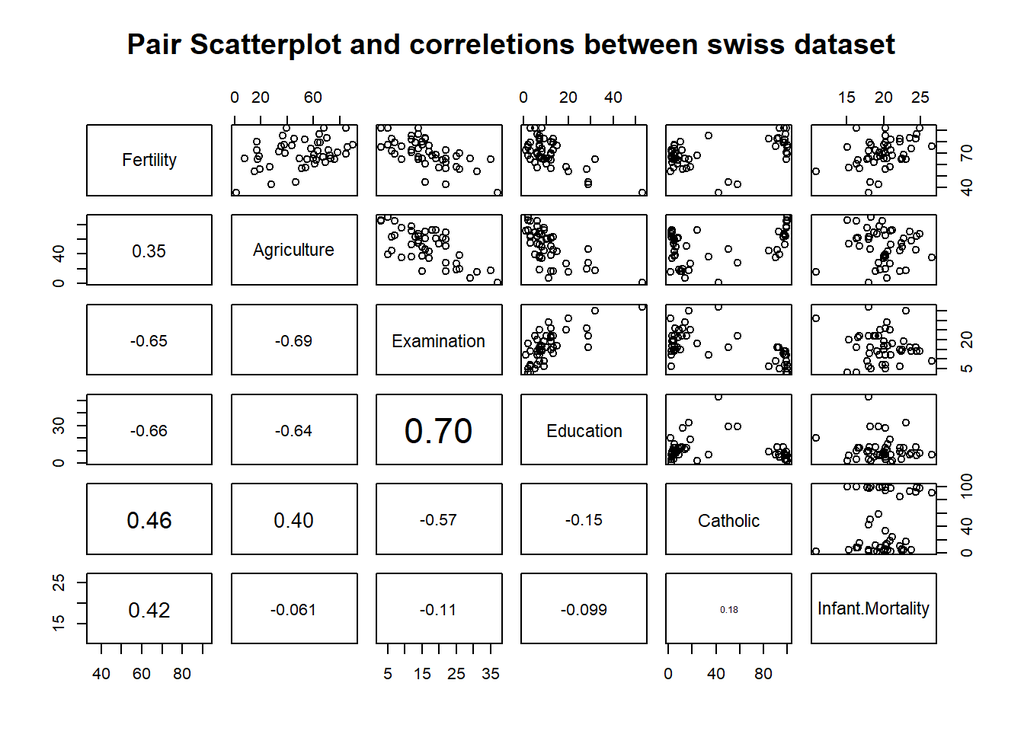

Using the above plot of pair scatterplota we can obatain usefull information aboout the conection between Fertility and the features chosen by the best model.Starting from the connection of Fertility and Agriculture we can see that higher percentage of males involved in agriculture occupation tend to have higher fertility.The connection between Fertility and Education seems negative meaning that higher percentage of education is connected to lower fertility.Moving to the connection of Fertility and Catholic there seems to be 2 clusters that they might be reprecent the diffrence between catholic and protestant fertility.Finally,the connection between Fertility and Infant.Mortality is positive. In conclusion,the feature chosen as we can see from the scatterplots and the correlations between Fetility have a large impact on explaing Fertility.Moreover the fact that Examination was not chosen by the model might be because there is high correlation between Examination and Education and the effect both on the model is very small.

## Assignment 4

### 1

[figure not shown]

### 2

Lets denote Moisture as $\mathbf{y} = \left[\begin{array}{rrr}y_1,y_2,..,y_n\end{array}\right]$ and Protein as $\mathbf{x} = \left[\begin{array}{rrr}x_1,x_2,..,x_n\end{array}\right]$

The polynomial model up to power $k$ can be expressed as : $y\sim N(X\beta+\epsilon,\sigma^2)$ where : $\beta$ is a vector $\mathbf{\beta} = \left[\begin{array}{rrr}\beta_1,\beta_2,..,\beta_n\end{array}\right]$ and $X$ is a matrix $\mathbf{X} = \left[\begin{array}{rrr}1,x_1,..,x_1^k\\1,x_2,...x_2^k\\...........\\1,x_n,...x_n^k\end{array}\right]$

we allready know that maximizing likelihood is equivalent to minimaxing the negative log likelihood. $min-\log( \left( \frac{1}{\sqrt(2\pi\sigma)^n } \right) e ^-\left( \frac{\sum_{i=1}^{n}(y_i-X_i\beta)^2}{\sqrt(2\sigma^2) } \right)$ $=n\log \sqrt (2\pi\sigma)+ \left( \frac{1}{2\sigma^2} \right) \sum_{i=1}^n(y_i-X_i\beta)^2$= $= \left( \frac{1}{2\sigma^2} \right) \sum_{i=1}^n(y_i-\hat{y_i})^2$ (1) from 1 we can conlude that minimizing -log is equivalent to minimizing MSE.

### 3

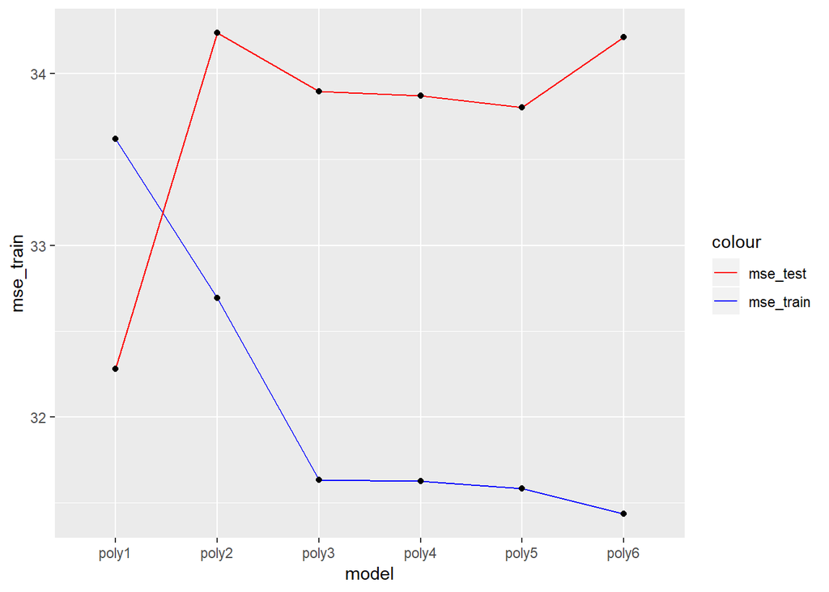

### 4

```
## [1] "The number of coefficients with the intercept are :"
```

```
## [1] 64
```

```
## [1] "The vslues of coefficients are :"
```

```
##   (Intercept)      Channel1      Channel2      Channel4      Channel5
##      7.093133  10559.893784 -12636.966607   8489.323117 -10408.966948
##      Channel7      Channel8     Channel11     Channel12     Channel13
##  -5376.017738   7215.595409  -9505.520235  37240.918374 -41564.546571
##     Channel14     Channel15     Channel17     Channel19     Channel20
##  34938.179314 -23761.450875   4296.572462  14279.808102 -23855.616123
##     Channel22     Channel24     Channel25     Channel26     Channel28
##  18444.905722 -20138.426065  18137.431996  -7670.318234  20079.898191
##     Channel29     Channel30     Channel32     Channel34     Channel36
## -36351.013717  18071.275531   3838.013358  -9242.884498   8070.938452
##     Channel37     Channel39     Channel40     Channel41     Channel42
##  -9045.587624  18664.454171 -20069.708579  22257.776227 -21760.853228
##     Channel45     Channel46     Channel47     Channel48     Channel50
##  18145.803786  -8225.696060  -4986.549169   2876.074542 -13009.409717
##     Channel51     Channel52     Channel54     Channel55     Channel56
##  29251.160946 -26833.976402  30954.861519 -35183.287363  14912.986496
##     Channel59     Channel60     Channel61     Channel63     Channel64
##  -8030.277501  13071.415506  -7850.189324  15059.274961 -19909.466348
##     Channel65     Channel67     Channel68     Channel69     Channel71
##   4190.183533  13850.508143 -25873.365427  18362.384676  -9223.909939
##     Channel73     Channel74     Channel78     Channel79     Channel80
##  12456.497755  -5624.411385  -7927.104791  15473.187794 -22391.894812
##     Channel81     Channel84     Channel85     Channel87     Channel88
##  13852.452651 -11442.629734  20228.671387 -15938.315283   5647.072201
##     Channel92     Channel94     Channel98     Channel99
##   6595.995241  -5497.846381  -8728.596111   8554.587048
```

```
## [1] "The mean squared error is :"
```

```
## [1] 0.8598985
```

We observe that using stepAIC the best model returned is a model with 63 plus one for interept and the corresponding features listed above.

### 5

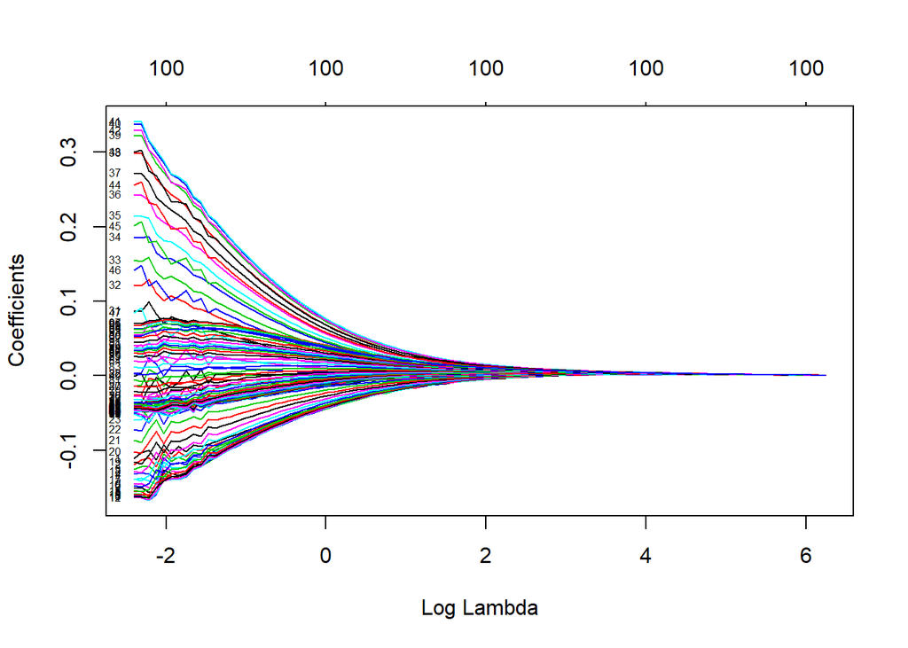

```
## [1] 0.09030492
```

### 6

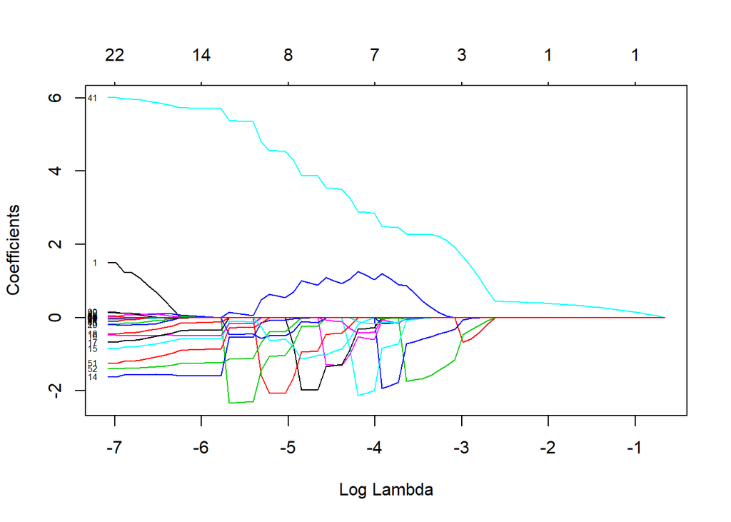

From the graph of coefficients and log(lambda) we can see that the effect of LASSO regression as lambda increases is penalizing coefficients and turn them to zero.In oppose to ridge regression in lasso for diffent lamda parameter we can have model where some coeeficients are 0 so lasso regression does both parameter shrinkage and variable selection automatically.

### 7

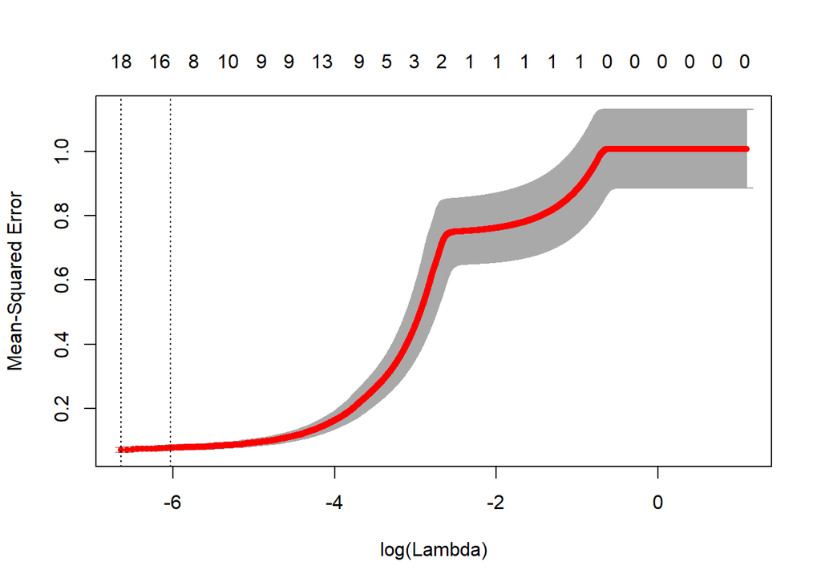

```
## [1] "The minimun lambda obtained is:"
```

```
## [1] 0.0013
```

```
## [1] "The 1se lambda obtained is:"
```

```
## [1] 0.0024
```

```
## [1] "The number of coefficients is :"
```

```
## [1] 12
```

```
## [1] "The minimum MSE score obtained is :"
```

```
## [1] 0.0708798
```

The minimum lambda returned is 0.0013 which coresponds to the best model that may be too complex of slightly overfitted.The 1se lambda is 0.0024 which returns the simplest model that has comparable error to the best model with lambda min.The number of the variables selected by the model are 12. Analyzing the plot showing the dependance of cv score with the penalty parameter lambda we can see that the MSE is growing rapidly as lambda increases and then after a value of lambda is reaches a plateu.

## Appendix

```r
##Assignment 1
spam<-readxl::read_excel("spambase.xlsx")
#spam$Spam<-as.factor(spam$Spam)
#levels(spam$Spam)<-c("not spam","spam")
###1
n=dim(spam)[1]
set.seed(12345)
id=sample(1:n, floor(n*0.5))
train=spam[id,]
test=spam[-id,]

model1<-glm(Spam~.,data=train,family = binomial(link = "logit"))
pred_train<-predict(model1,train,type="response")
pred_test<-predict(model1,test,type="response")
broom::glance(model1) # use to see diagnostics of the model
fit.pred_train<-ifelse(pred_train>0.5,1,0)
fit.pred_test<-ifelse(pred_test>0.5,1,0)
#confusion matrix for train data
table(fit.pred_train,train$Spam,dnn = c("Predictions","True train values"))

train_accuracy<-(803+344)/(803+142+344+81)
train_precision<-(803)/(803+81)
cat("=====================================\nAccuracy on train data is: ", train_accuracy,"\nPrecision on train data is:",train_precision)

#confusionmatrix for test data
table(fit.pred_test,test$Spam,dnn = c("Prediction","True test values"))
test_accuracy<-(791+336)/(791+97+146+336)
test_precision<-791/(791+97)
cat("=====================================\nAccuracy on test data is: ", test_accuracy,"\nPrecision on test data is:",test_precision)

#model accuracy on train data
mean(train$Spam==fit.pred_train)
#model accuracy on test data
mean(test$Spam==fit.pred_test)

#ROC
ROC<-pROC::roc(test$Spam,fit.pred_test)#using the package pROC
plot(ROC,color="blue")
pROC::auc(ROC)

#We can also use package POCR
# auc<-performance(prediction(fit.pred_test,test$Spam),"auc")
# unlist(slot(auc, "y.values"))

#calculate misclassification errors wtih mis_error

mis_error<-function(X,X1){
  n<-length(X)
  return(1-sum(diag(table(X,X1)))/n) #misclassification error function
}

miserror_train<-mis_error(fit.pred_train,train$Spam)
miserror_test<-mis_error(fit.pred_test,test$Spam)
cat("=====================================\nMissclasification error in train: ", miserror_train,"\nMissclasification error in test:",miserror_test)

###2
fit.pred_train1<-ifelse(pred_train>0.9,1,0)
fit.pred_test1<-ifelse(pred_test>0.9,1,0)
#confusion matrix for train data
table(fit.pred_train1,train$Spam,dnn = c("Predictions","True train values"))
#confusionmatrix for test data
table(fit.pred_test1,test$Spam,dnn = c("Predictions","True train values"))

miserror_train1<-mis_error(fit.pred_train1,train$Spam)
miserror_test1<-mis_error(fit.pred_test1,test$Spam)
cat("=====================================\nMissclasification error in train: ", miserror_train1,"\nMissclasification error in test:",miserror_test1)

#model accuracy on train data
mean(train$Spam==fit.pred_train1)
#model accuracy on test data
mean(test$Spam==fit.pred_test1)
###3
library(kknn)
s<-spam
s$Spam<-as.factor(s$Spam)
n=dim(s)[1]
set.seed(12345)
id=sample(1:n, floor(n*0.5))
strain=s[id,]
stest=s[-id,]
#first train the model with train,train and then make predictions
(knn<-kknn(Spam ~ ., strain,strain, k = 30))
table(knn$fit,strain$Spam,dnn=c("Predicted class","Real class"))
e1<-mis_error(knn$fit,strain$Spam)


(knn1<-kknn(Spam ~ .,strain,stest, k = 30))
table(knn1$fit,stest$Spam,dnn=c("Predicted class","Real class"))
e2<-mis_error(knn1$fit,stest$Spam)


cat("=====================================\nMissclasification error in train: ", e1,"\nMissclasification error in test:",e2)
plot(knn)
###4
(knn3<-kknn(Spam ~ .,strain,strain, k = 1))
table(knn3$fit,strain$Spam,dnn=c("Predicted class","Real class"))
e3<-mis_error(knn3$fit,strain$Spam)

(knn4<-kknn(Spam ~ .,strain,stest, k = 1))
table(knn4$fit,stest$Spam,dnn=c("Predicted class","Real class"))
e4<-mis_error(knn4$fit,stest$Spam)


cat("=====================================\nMissclasification error in train: ", e3,"\nMissclasification error in test:",e4)

feature_selection<-function(X,Y,N){

  n<-ncol(X)
  idx<-1:2^n-1
  t<-vector()
  mat<-sapply(idx, function(id){
    t<-cbind(t,as.integer(intToBits(id)))
    t})
  m<-mat[1:n,2:ncol(mat)]
  ######################################
  set.seed(12345)
  #X<-X[sample(nrow(X)),]
  #Y<-Y[sample(length(Y))]
  id<-sample(nrow(X))
  X<-X[id,]
  Y<-Y[id]
  #Create N equally size folds
  folds <- cut(seq(1,nrow(X)),breaks=N,labels=FALSE)
  d<-matrix(0,nrow=N,ncol=dim(m)[2])
  n_features<-rep(0,ncol(d))
  for (i in 1:ncol(m)){
    x<-X[which(m[,i]==1)]
    n_features[i]<-ncol(x)
    for(j in 1:N){

      testIndexes <- which(folds==j,arr.ind=TRUE)
      testX <- as.matrix(x[testIndexes, ])
      trainX <- as.matrix(x[-testIndexes, ])
      testy<-Y[testIndexes]
      trainy<-Y[-testIndexes]
      trainX<-cbind(1,trainX)
      testX<-cbind(1,testX)

      w<-round(as.vector(solve(t(trainX)%*%trainX)%*%t(trainX)%*%trainy),3)
      y_pred<-round(as.matrix(testX%*%w),3)
      sse<-sum((testy-y_pred)^2)
      d[j,i]<-sse
    }
  }
 d<-d
 s<-apply(d, MARGIN = 2, function(x) mean(x, na.rm=TRUE))
  bindex<-which(s==min(s))
  best_comb<-X[which(m[,bindex]==1)]
  print(list("best combination"=colnames(best_comb),"best cv score"=s[bindex]))
  plot(x=seq(s),y=s,type="p",xlab="number of features",ylab="CV score",col=ifelse(s==s[bindex],"red","black"))
}


Y<-swiss[,"Fertility"]
X<-swiss[!names(swiss)%in%c("Fertility")]
D<-feature_selection(X,Y,5)

library(ggplot2)
tecator<-readxl::read_excel("tecator.xlsx")

##1
p<-ggplot(tecator,aes(x=Moisture,y=Protein))+geom_point(color='darkblue')+ggtitle("ScatterPlot Moisture vs Protein")+theme_bw()+
  geom_smooth(method = 'nls', formula = y ~ x^b, start = list(b=3),se=FALSE)
p
##3

n=dim(tecator)[1]
set.seed(123)
id=sample(1:n, floor(n*0.5))
traindata=tecator[id,]
validata=tecator[-id,]

d<- matrix(0, ncol = 2, nrow = 6)
colnames(d)<-c("mse_train","mse_test")
rownames(d)<-c("poly1","poly2","poly3","poly4","poly5","poly6")

for (i in 1:6){
  m<-lm(Moisture~poly(Protein,i),data=traindata)
  preds_valid<-predict(m,validata)
  preds_train<-predict(m,traindata)

  mse <- function(true,predicted) {
    return (mean((true-predicted)^2))
    }

  mse_train<-mse(traindata$Moisture,preds_train)
  mse_test<-mse(validata$Moisture,preds_valid)
  d[i,1]<-mse_train
  d[i,2]<-mse_test
}

dd<-as.data.frame(d)
dd$model<-rownames(dd)
###plot with ggplot
p1<-ggplot(dd,aes(x=model,y=mse_train,group=1))+geom_point(color="blue")+geom_line(colour="blue")
p1+geom_point(data=dd, aes(x=model,y=mse_test,color="red"))+geom_line(data=dd,aes(x=model,y=mse_test,color="red"))

###plot with plotly
library(plotly)

pp <- plot_ly(dd, x = ~model, y = ~mse_train, name = 'mse_train', type = 'scatter',mode="lines+markers")%>%
  add_trace(x=~model,y = ~mse_test, name =" mse_test", mode = 'markers+lines')
pp
#====================Use the entire dataset for the rese=======================================
###4
library(MASS)
tecator_fat<- tecator[!names(tecator)%in%c("Sample","Protein","Moisture")]
mod<-lm(Fat~.,data= tecator_fat)
step<-stepAIC(mod,direction="both",trace=F)
summary(step)
#the coefficients selected are
length(step$coefficients) # 64 wirh the intercept
mean((step$fit-tecator_fat$Fat)^2) #mean square error
###5##Ridge
library(glmnet)

covariates<-scale(tecator_fat[,-101])
responses<-scale(tecator_fat[,101])
mod1<-glmnet(as.matrix(covariates),responses,family="gaussian",alpha=0)
min_lambda=min(mod1$lambda)
plot(mod1,xvar="lambda",label=TRUE)
###6##LASSO
mod2<-glmnet(as.matrix(covariates),responses,family="gaussian",alpha=1)
plot(mod2,xvar="lambda",label=TRUE)
###7##CV-LASSO###
mod3<-cv.glmnet(as.matrix(covariates),responses,alpha=1,family="gaussian",lambda=seq(0,2,0.0001))
plot(mod3)
mod3$lambda.min
mod3$lambda.1se
co<-coef(mod3,s="lambda.1se")
length(co@x) #co@p
min(mod3$cvm)

#mse for LASSO
mean((tecator_fat$Fat-predict(mod3,tecator_fat[-101],s="lambda.1se"))^2)
```